# Presentación de la Asignatura Tecnologías para el Análisis de Datos Masivos

17/10/2020

## ¿Quiénes somos?

[figure not shown]

Juan Gabriel Gomila

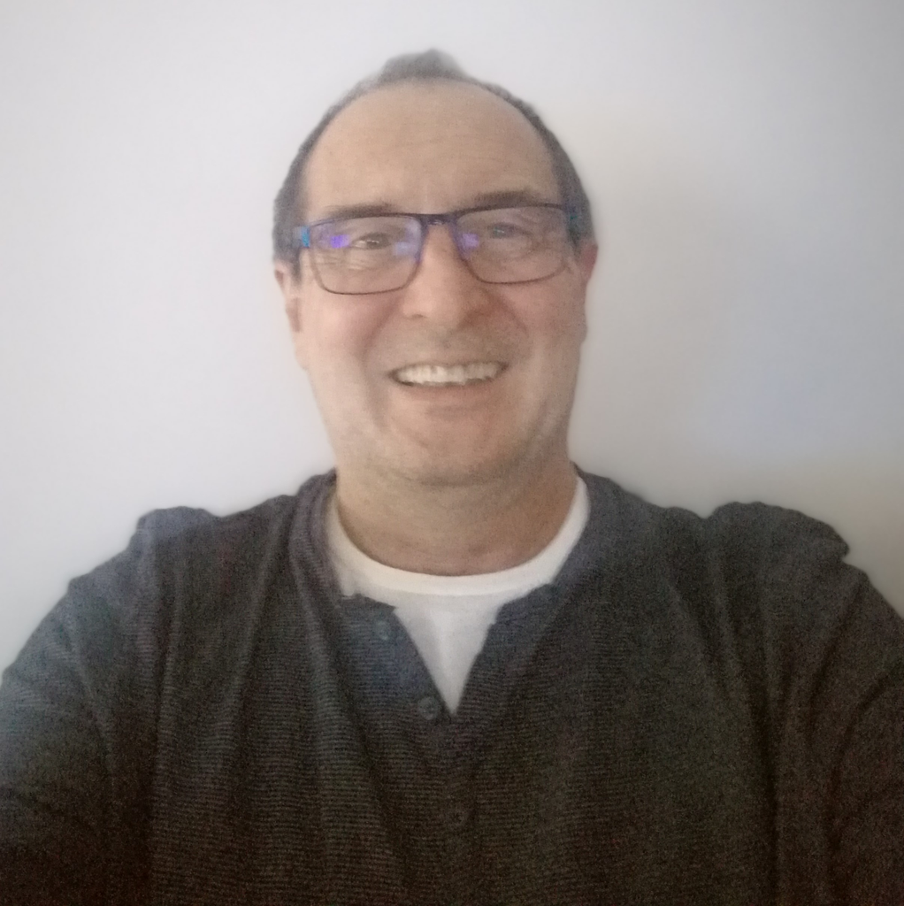

Ricardo Alberich

## ¿Quiénes somos? Juan Gabriel Gomila

- [Departamento de Ciencias Matemáticas e Informática e la UIB](https://www.uib.es/es/lauib/Govern-i-organitzacio/estructura/Departaments/dmi/)
- [Profesor asociado del área de Ciencia de la Computación e Inteligencia artificial](https://www.uib.eu/personal/ABjE5ODE5MA/)
- [Licenciado en Matemáticas por la UIB](https://www.uib.es/es/)
- [CEO Frogames](https://frogames.es/)
- Y más cosas…
- Email

## ¿Quiénes somos? Ricardo Alberich

- [Departamento de Ciencias Matemáticas e Informática e la UIB](https://www.uib.es/es/lauib/Govern-i-organitzacio/estructura/Departaments/dmi/)
- [Profesor Titular del área de Ciencia de la Computación e Inteligencia Artificial](https://www.uib.es/es/personal/ABDI0ODk/)
- [Licenciado en matemáticas por la Universidad de Valencia](https://www.uv.es/uvweb/universidad/es/universidad-valencia-1285845048380.html)
- [Doctor en informática por la UIB](https://www.uib.cat/)
- Email

## Asignatura 11630 - Tecnologías para el Analisis de Datos Masivos

- [Guía docente(català)](https://academic.uib.es/doa/consultaPublica/look%5bconpub%5dMostrarPubGuiaDocAs?entradaPublica=true&idiomaPais=ca.ES&_anoAcademico=2020&_codAsignatura=11630)
- Cronograma: Horarios de clase
- [Espacio discord de la asignatura](https://discord.gg/uphEZMR)
- [Espacio moodle de la UIB de la asignatura](https://ad.uib.es/estudis2021/course/view.php?id=1524)

## Temas de la asignatura

Todo será de carácter práctico y aplicado. Ya se profundizará en otras asignaturas según los itinerarios que hayáis elegido.

Grandes temas (no necesariamente en este orden) son tecnologías para:

- Tema 1 Repaso de estadística descriptiva, inferencia y Introducción a R y RStudio Este será un tema transversal al curso cubierto con los materiales del curso online de Udemy los anexos.
- Tema 2. Manipulación de datos con Tidyverse. Este tema se tratará sólo en R pero se extensible al lenguaje python
- Tema 3. Machine Learning y Aprendizaje Estadístico
- Tema 4 Protección de datos y Legislación.

## Contenidos Tema 3 ( y 1 )

- Parte 1 - Preprocesamiento de datos
- Parte 2 - Regresión: Regresión Lineal Simple, Regresión Lineal Múltiple, Regresión Polinomial, SVR, Regresión en Árboles de Decisión y Regresión con Bosques Aleatorios
- Parte 3 - Clasificación: Regresión Logística, K-NN, SVM, Kernel SVM, Naive Bayes, Clasificación con Árboles de Decisión y Clasificación con Bosques Aleatorios
- Parte 4 - Clustering: K-Means, Clustering Jerárquico
- Parte 5 - Aprendizaje por Reglas de Asociación: Apriori, Eclat

## Contenidos Tema 3 ( y 2 )

Continuación

- Parte 6 - Reinforcement Learning: Límite de Confianza Superior, Muestreo Thompson
- Parte 7 - Procesamiento Natural del Lenguaje: Modelo de Bag-of-words y algoritmos de NLP
- Parte 8 - Deep Learning: Redes Neuronales Artificiales y Redes Neuronales Convolucionales
- Parte 9 - Reducción de la dimensión: ACP, LDA, Kernel ACP
- Parte 10 - Selección de Modelos & Boosting: k-fold Cross Validation, Ajuste de Parámetros, Grid Search, XGBoost

## Materiales del curso (enlaces gratuitos a materiales)

- [Curso completo de Estadística descriptiva - RStudio y Python](https://www.udemy.com/course/estadistica-descriptiva/?couponCode=UIBDATOS2020)
- [Curso completo de R para Data Science con Tidyverse](https://www.udemy.com/course/r-for-data-science/?couponCode=UIBDATOS2020)
- [Machine Learning de la A a la Z: R y Python para data science](https://www.udemy.com/course/machinelearning-es/?couponCode=UIBDATOS2020)

## Enlaces a repositorios de datos

1. [Kaggle](https://www.kaggle.com/)
2. [Sciencie (Nature)](https://www.nature.com/sdata/policies/repositories)
3. [Data Repositories](http://oad.simmons.edu/oadwiki/Data_repositories)
4. [UCI (Machine learningrepository)](https://archive.ics.uci.edu/ml/datasets.ph)

## Material cursos probabilidad y estadística básicos

1. [Probabilidad y variables aleatorias para ML con R y Python bookdown](https://joanby.github.io/bookdown-probabilidad)
   - [Presentaciones](https://joanby.github.io/probabilidad)
   - [Presentaciones repositorio](https://github.com/joanby/probabilidad)
   - [Ejercicios, en Rmd, pdf](https://github.com/joanby/probabilidad/tree/master/ejercicios)
   - [Shiny](https://joanby.shinyapps.io/DistribucionesNotables/)
2. [Curso completo de estadística inferencial con R y Python bookdown. EN CONSTRUCCIÓN](https://joanby.github.io/bookdown-estadistica-inferencial)
   - [Presentaciones](https://joanby.github.io/estadistica-inferencial)
   - [Presentaciones repositorio](https://github.com/joanby/estadistica-inferencial)
   - [Shiny intervalos de confianza y contrastes hipótesis. EN CONSTRUCCIÓN](https://joanby.shinyapps.io/contrastes-hipotesis/)
3. [Página de itinerarios del profesor Juan Gabriel Gomila](https://frogames.es/rutas-de-aprendizaje/)

## Libros del entorno de R y Rstudio

En general los libros gratuitos de (https://bookdown.org/)

Dos libros, entre otros, básicos que introducen a las librerías [tidyverse del entorno de Rstudio](https://rstudio.com/) son

1. [R for Data Science](https://r4ds.had.co.nz/)
2. [Tidy text](https://www.tidytextmining.com/)
3. [Hay muchos más libros en bookdown.org](https://bookdown.org)

## Metodología

- Teoría y materiales explicados en vídeos online. (Home work)
- Las clase en linea en el discord de la asignatura y BBcollaborate de moodle de la UIB
- En las clases online, repasaremos conceptos de los videos y haremos más ejemplos, profundizaremos y resolveremos consultas y dudas,
- **Recomendación** las primeras semanas sólo tenéis esta asignatura habrá MUCHO TRABAJO y tendréis que invertir muchas horas (15 horas de clase y unas 45 más de trabajo). El objetivo es conseguir un nivel MÍNIMO para poder cursar el resto de asignaturas del máster con garantías de éxito.

## Actividad de evaluación

- Estadística descriptiva: R + python: 20%
- Manipulación de Datos: Tidyverse: 20%
- Trabajo Final (individual): Machine Learning : 50% nota mínima 5/10) recuperable.
- Cuestionarios, interacción en clase y trabajos cursos online: 10%